# Curso de Ilustração Científica para Artigos

# Introdução

Neste documento você poderá refazer alguns dos gráficos apresentados durante o **Curso Rápido de Ilustração Científica para Artigos**. Os gráficos foram feitos utilizando o conjunto de dados [*World Happiness Report 2021*](https://www.kaggle.com/ajaypalsinghlo/world-happiness-report-2021) disponível no Kaggle. Fique a vontade para adaptar e utilizar os códigos para uso pessoal, mas lembre-se de fazer as devidas alterações de acordo com o seu público e a sua mensagem. Este documento é um complemento à apostila do curso.

O objetivo deste material é apresentar alguns modelos de gráficos simples feitos no *R* utilizando pacote *ggplot2*. Esses gráficos são úteis na representação de distribuição de dados, relação entre variáveis e quantidades, conforme especificado nos tópicos deste documento. Note que há varias outras possibilidades de representação gráfica para atender esses objetivos. A escolha do tipo de gráfico e dos elementos a serem priorizados depende do contexto da comunicação visual, em que quatro perguntas essenciais devem ser consideradas:

- Por quê?
- O quê?
- Para quem?
- Como?

# Gráficos

## Carregando pacotes necessários

```r
library(ggridges)
```

```r
library(ggplot2)
library(RColorBrewer)
library(dplyr)
```

## Carregando o conjunto de dados “World Happiness Report”

```r
df = read.csv("world-happiness-report-2021.csv", head=T, sep = ",", na.strings = NA, encoding = "UTF-8", dec = ",")
```

Transformando varíaveis

```r
df[3:ncol(df)] = data.frame(sapply(df[3:ncol(df)], as.numeric))
```

Filtandro apenas colunas que nos interessam

```r
df = df[,c(1:3, 7:13)]
```

Alterando o nome das colunas

```r
colnames(df) = c("País", "Região", "NotaGeral", "RendaPerCapita", "SuporteSocial",
                 "ExpectativaDeVidaSaudável", "LiberdadeParaTomarDecisões",
                 "Generosidade", "PercepçãoDeCorrupção",
                 "NotaDeDistopia")
```

## Distribuições

Observando a distribuição dos dados:  
**Distribuição de generosidade por região** - Densidades

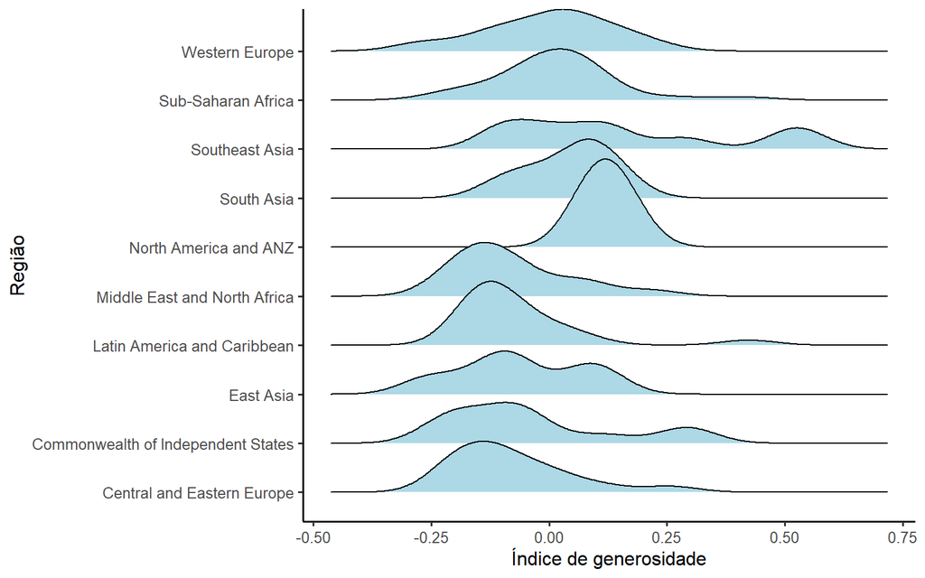

```r
ggplot(df, aes(x = Generosidade, y = Região)) +
  geom_density_ridges(fill = "lightblue") +
  scale_x_continuous(name= "Índice de generosidade")+
  scale_y_discrete(name = "Região")+
  theme_classic(base_size = 12)
```

**Histograma dos dados de Suporte Social**

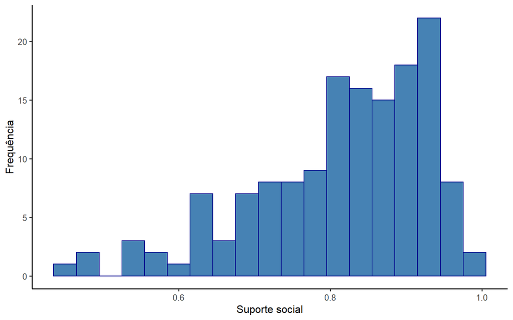

```r
d1 = ggplot(df, aes(x = SuporteSocial)) +
  geom_histogram(binwidth = 0.03, fill = "steelblue", color = "darkblue") +
  guides(color=guide_legend(title="Região")) +
  scale_x_continuous(name= "Suporte social")+
  scale_y_continuous(name = "Frequência") +
  theme_classic(base_size = 12)
d1
```

**Gráfico de densidade da distribuição dos dados de Suporte Social**  
Mesma informação do histograma, representada de outra forma.

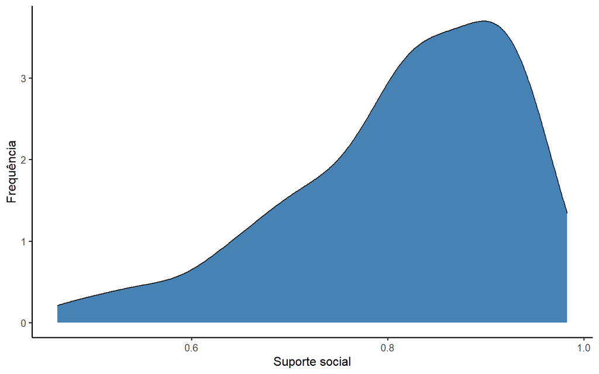

```r
d2 = ggplot(df, aes(x = SuporteSocial)) +
  geom_density(fill = "steelblue") +
  guides(color=guide_legend(title="Região")) +
  scale_x_continuous(name= "Suporte social")+
  scale_y_continuous(name = "Frequência") +
  theme_classic(base_size = 12)
d2
```

**Gráfico de violino da distribuição dos dados de Suporte Social para cada categoria de Região**

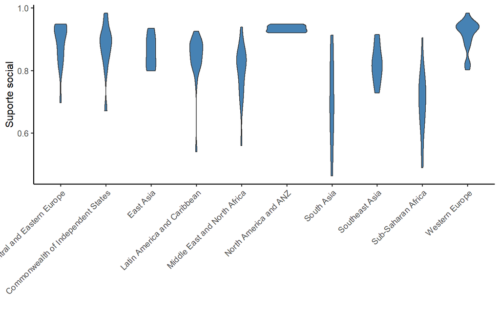

```r
d3 = ggplot(df, aes(x = Região, y = SuporteSocial)) +
  geom_violin(fill = "steelblue") +
  scale_x_discrete(name= "")+
  scale_y_continuous(name = "Suporte social") +
  theme_classic(base_size = 12) +
  guides(x = guide_axis(angle = 45))
d3
```

**Boxplot da distribuição dos dados de Suporte social para cada categoria de Região**

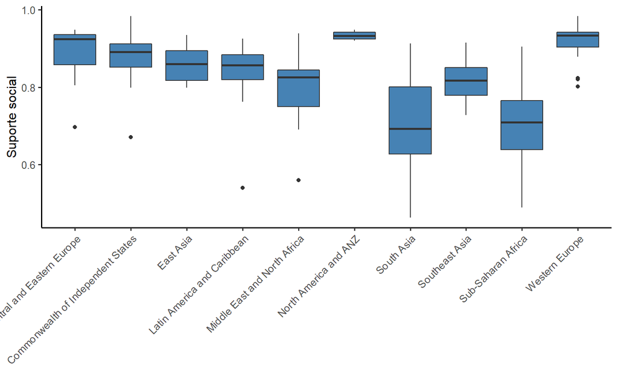

```r
d4 = ggplot(df, aes(x = Região, y = SuporteSocial)) +
  geom_boxplot(fill = "steelblue") +
  guides(color=guide_legend(title="Região")) +
  scale_x_discrete(name= "")+
  scale_y_continuous(name = "Suporte social") +
  theme_classic(base_size = 12) +
  guides(x = guide_axis(angle = 45))
d4
```

**Combinando os graficos de distribuição dos dados de Suporte social em um painel**

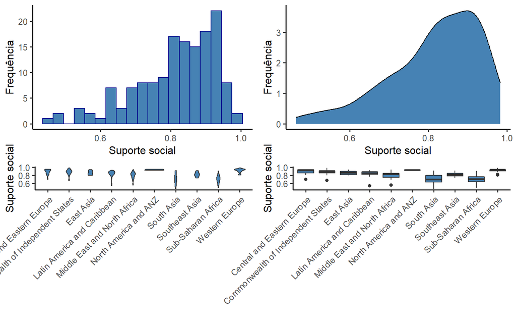

```r
d = cowplot::plot_grid(d1, d2, d3, d4,  ncol = 2, nrow = 2)
d
```

## Relações

[figure not shown]

```r
ggplot(df, aes(x = SuporteSocial, y = RendaPerCapita, color = Região)) +
  geom_point() +
  guides(color=guide_legend(title="Região")) +
  scale_x_continuous(name= "Renda per capita")+
  scale_y_continuous(name= "Suporte social") +
  theme_classic()
```

[figure not shown]

```r
df %>%
  filter(.$Região == "Latin America and Caribbean" | .$Região == "Southeast Asia") %>%
  ggplot(., aes(x = SuporteSocial, y = RendaPerCapita, color = Região)) +
  geom_point() +
  geom_smooth(aes(color = Região, fill =  Região), method = "lm") +
  guides(color=guide_legend(title="Região"), fill=guide_legend(title="Região")) +
  scale_color_manual(values = c('#af8dc3','#7fbf7b')) +
  scale_fill_manual(values = c('#af8dc3','#7fbf7b')) +
  scale_x_continuous(name= "Renda per capita")+
  scale_y_continuous(name= "Suporte social") +
  theme_classic()
```

*Outro exemplo*  
Combinado mais de duas varíaveis no gráfico para observar relação **Gráfico de pontos América Latina**

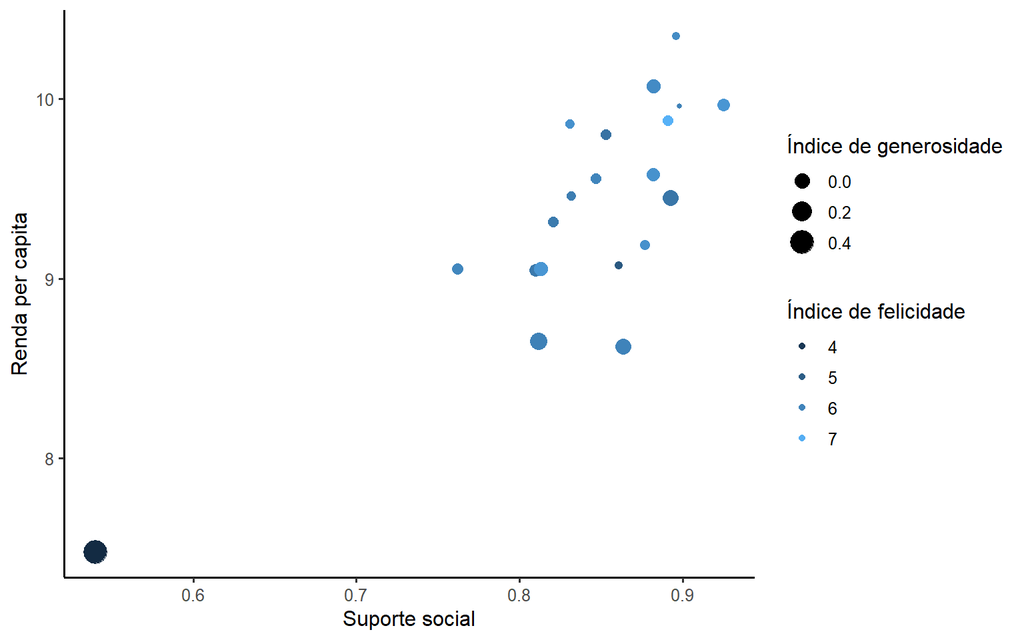

```r
df %>%
  filter(.$Região == "Latin America and Caribbean") %>%
  arrange(., NotaGeral) %>%
  ggplot(., aes(x = SuporteSocial, y = RendaPerCapita, color = NotaGeral, size = Generosidade)) +
  geom_point() +
  scale_x_continuous(name= "Suporte social") +
  scale_y_continuous(name = "Renda per capita") +
  guides(color=guide_legend(title= "Índice de felicidade")) +
  guides(size=guide_legend(title= "Índice de generosidade")) +
  theme_classic(base_size = 12)
```

## Quantidades

Quantidade de paises por região, que estão participando da pesquisa **Gráfico de barras**

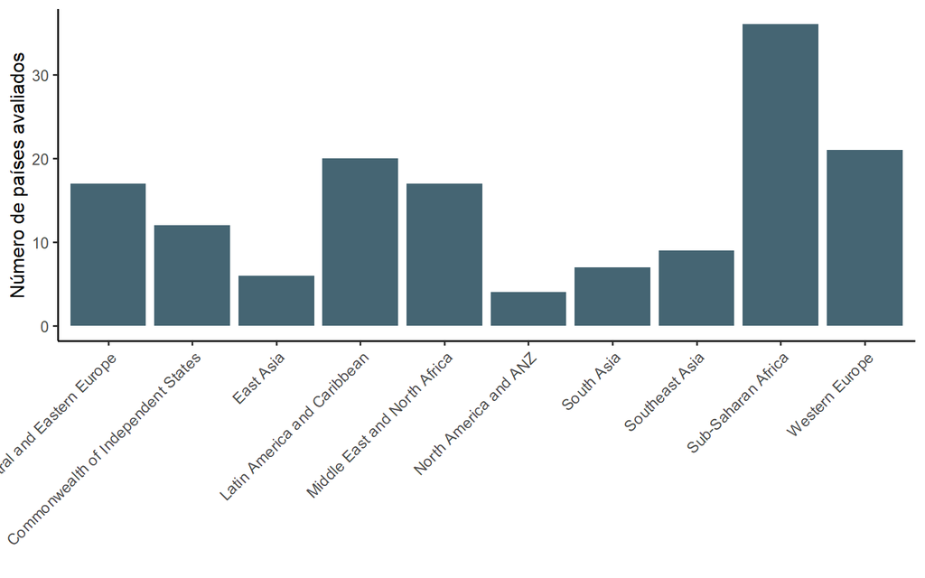

```r
df %>%
  group_by(., Região) %>%
  count() %>%
  ggplot(., aes(x = Região, y = n)) +
  scale_y_continuous(name = "Número de países avaliados") +
  geom_col(fill = "#456573" ) +
  scale_x_discrete(name= "") +
  guides(x = guide_axis(angle = 45)) +
  theme_classic(base_size = 12)
```

Outra opção, neste caso, menos eficaz para comunicar o número de paises por região para este conjunto de dados. **Gráfico de pontos com escala de cor para possível impressão em escala de cinza**

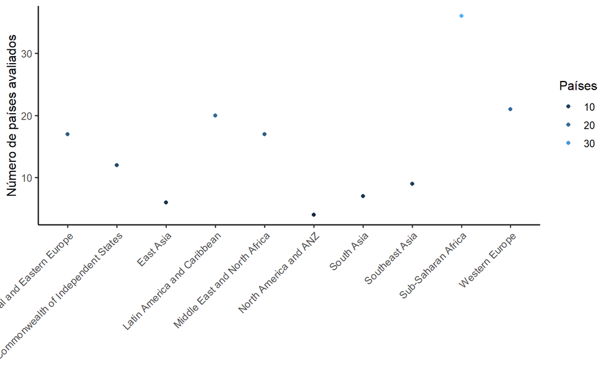

```r
df %>%
  group_by(., Região) %>%
  count(., Região) %>%
  ggplot(., aes(x = Região, y = n)) +
    geom_point(aes(colour = n)) +
    scale_x_discrete(name= "") +
    scale_y_continuous(name = "Número de países avaliados") +
    guides(x = guide_axis(angle = 45)) +
    guides(color=guide_legend(title= "Países")) +
    guides(size=guide_legend(title= "")) +
    theme_classic(base_size = 12)
```

Para conhecer mais sobre gráficos, recomendamos a leitura do livro [*Fundamentals of Data Visualization*](https://clauswilke.com/dataviz/) de Claus O. Wilke.

Para aprender sobre sobre o *ggplot2*, há muito material de qualidade disponível na internet, mas nós recomendamos o [guia oficial do pacote](https://ggplot2.tidyverse.org/) para conhecer as diversas possibilidades de uso.

Os dois materiais são gratuitos para acesso online.